# Interesting Visualizations

2022-09-12

# 1 Excess rentals in TfL bike sharing

TfL data: How many bikes were hired every single day:

```r
url <- "https://data.london.gov.uk/download/number-bicycle-hires/ac29363e-e0cb-47cc-a97a-e216d900a6b0/tfl-daily-cycle-hires.xlsx"
```

```r
# Use read_excel to read it as dataframe
bike0 <- read_excel(bike.temp,
                   sheet = "Data",
                   range = cell_cols("A:B"))

# change dates to get year, month, and week
bike <- bike0 %>%
  clean_names() %>%
  rename (bikes_hired = number_of_bicycle_hires) %>%
  mutate (year = year(day),
          month = lubridate::month(day, label = TRUE),
          week = isoweek(day))
```

### 1.0.1 Monthly changes in TfL bike rentals:

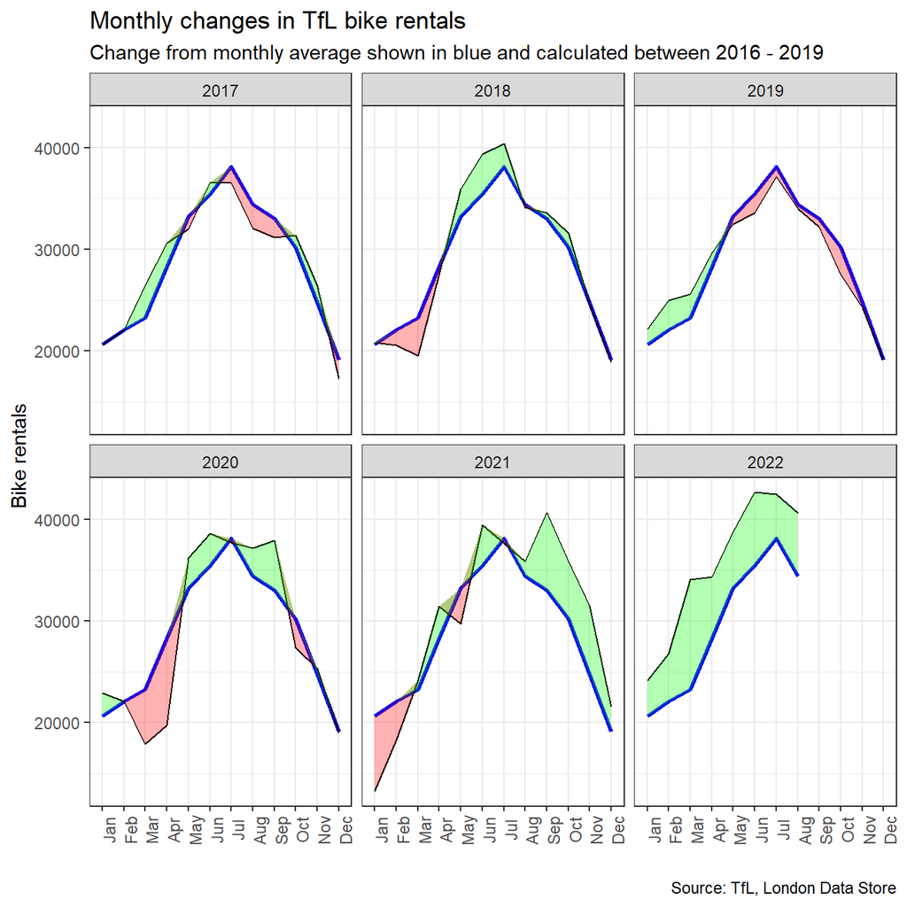

```r
# creating a data frame to calculate the monthly average for years 16 to 19
bike_16to19 <- bike %>%
  filter (year %in% 2016:2019) %>%
  group_by (month) %>%
  summarize (avg_bikes_16to19 = mean(bikes_hired))

# creating a data frame to calculate the monthly averages for each year from 17 to 22
bike_17to22 <- bike %>%
  filter (year %in% 2017:2022) %>%
  group_by (month, year) %>%
  summarize (avg_bikes_17to22 = mean(bikes_hired))

# joining the two data frames to create one data frame that can be used for the creation of the graph
joined <- left_join(bike_17to22, bike_16to19)

# plotting monthly changes in TfL bike rentals faceted by year
ggplot(joined, aes(x = month, group = year)) +
  geom_line(aes(y = avg_bikes_16to19), group = 1, color = "blue", size = 1) +
  geom_line(aes(y = avg_bikes_17to22, group = 1)) +
  geom_ribbon (aes (ymin = avg_bikes_17to22, ymax = pmax(avg_bikes_16to19, avg_bikes_17to22)), fill = "red", alpha=0.3) +
  geom_ribbon (aes (ymin = avg_bikes_16to19, ymax = pmax(avg_bikes_16to19, avg_bikes_17to22)), fill = "green", alpha=0.3) +
  facet_wrap(~ year) +
  theme_bw() +
  theme(axis.text.x = element_text(angle = 90)) +
  labs(title = "Monthly changes in TfL bike rentals",
       subtitle = "Change from monthly average shown in blue and calculated between 2016 - 2019",
       x = "",
       y = "Bike rentals",
       caption = "Source: TfL, London Data Store")
```

### 1.0.2 Percentage changes from the expected level of weekly rentals:

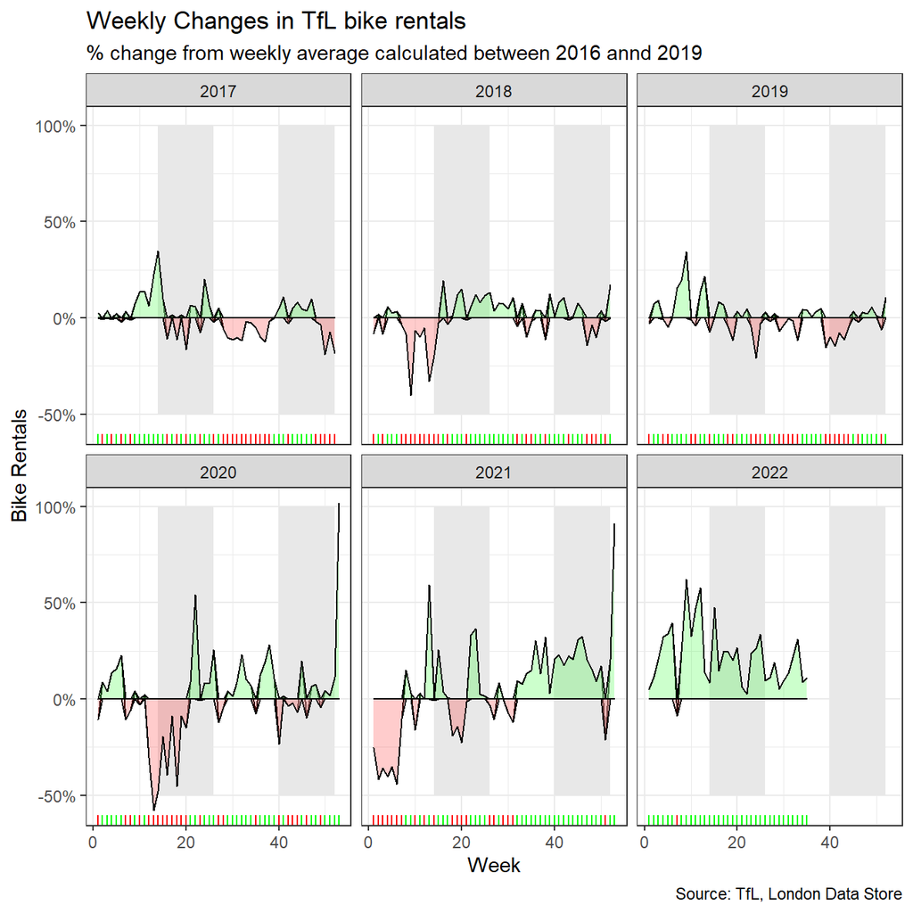

```r
# creating a data frame to calculate the weekly average for years 16 to 19
bike_16to19_weekly <- bike %>%
  filter (year %in% 2016:2019) %>%
  group_by (week) %>%
  summarize (avg_bikes_16to19_weekly = mean(bikes_hired))

# creating a data frame to calculate the weekly averages in bike rentals for each year from 17 to 22
bike_17to22_weekly <- bike %>%
  filter (year %in% 2017:2022) %>%
  group_by (week, year) %>%
  summarize (avg_bikes_17to22_weekly = mean(bikes_hired))

# joining the two data frames to create one data frame that can be used for the creation of the graph
joined_weekly <- left_join(bike_17to22_weekly, bike_16to19_weekly)

# adding two columns to calculate the percent change and filter out data value in week 52 of year 2022
joined_weekly_mutated <- joined_weekly %>%
  mutate (Excess_rentals = avg_bikes_17to22_weekly - avg_bikes_16to19_weekly) %>%
  mutate (Excess_rentals_Perc = Excess_rentals / avg_bikes_16to19_weekly * 100) %>%
  filter(!(week >= 52 & year == 2022)) %>%
  mutate(color_id = if_else(Excess_rentals_Perc > 0,
                          "Positive",
                          "Negative"))

# plotting the weekly percentage changes
ggplot(joined_weekly_mutated, aes(x = week, y = Excess_rentals_Perc)) +
  geom_line() +

# creating rectangles to highlight Q2 and Q4
  geom_rect(aes(x = week, xmin = 14, xmax = 26, ymin = -50, ymax = 100), fill = "grey", alpha = 0.01) +
  geom_rect(aes(x = week, xmin = 40, xmax = 52, ymin = -50, ymax = 100), fill = "grey", alpha = 0.01) +

  facet_wrap (~ year) +
  theme_bw() +

#adding fill in between lines and rug at the bottom
  geom_ribbon(aes(ymin=0, ymax=pmax(Excess_rentals_Perc,0)), fill="green", col="black", alpha=0.2) +
  geom_ribbon(aes(ymin=pmin(Excess_rentals_Perc,0), ymax=0), fill="red", col="black", alpha=0.2) +
  geom_rug(mapping = aes(color = color_id), sides = "b", show.legend = FALSE) +
  scale_color_manual(values = c("red", "green")) +
  scale_y_continuous(labels = scales::percent_format(scale = 1)) +
  labs(title = "Weekly Changes in TfL bike rentals",
       subtitle = "% change from weekly average calculated between 2016 annd 2019",
       x = "Week",
       y = "Bike Rentals",
       caption = "Source: TfL, London Data Store")
```

# 2 Share of renewable energy production in the world

Source: The National Bureau of Economic Research (NBER) dataset on the adoption of about 200 technologies in more than 150 countries since 1800. This is the[Cross-country Historical Adoption of Technology (CHAT) dataset](https://www.nber.org/research/data/cross-country-historical-adoption-technology).

Load Data:

```r
technology <- readr::read_csv('https://raw.githubusercontent.com/rfordatascience/tidytuesday/master/data/2022/2022-07-19/technology.csv')

#get all technologies
labels <- technology %>%
  distinct(variable, label)

# Get country names using 'countrycode' package
technology <- technology %>%
  filter(iso3c != "XCD") %>%
  mutate(iso3c = recode(iso3c, "ROM" = "ROU"),
         country = countrycode(iso3c, origin = "iso3c", destination = "country.name"),
         country = case_when(
           iso3c == "ANT" ~ "Netherlands Antilles",
           iso3c == "CSK" ~ "Czechoslovakia",
           iso3c == "XKX" ~ "Kosovo",
           TRUE           ~ country))

#make smaller dataframe on energy
energy <- technology %>%
  filter(category == "Energy")

# download CO2 per capita from World Bank using {wbstats} package
# https://data.worldbank.org/indicator/EN.ATM.CO2E.PC
co2_percap <- wb_data(country = "countries_only",
                      indicator = "EN.ATM.CO2E.PC",
                      start_date = 1970,
                      end_date = 2022,
                      return_wide=FALSE) %>%
  filter(!is.na(value)) %>%
  #drop unwanted variables
  select(-c(unit, obs_status, footnote, last_updated))

# get a list of countries and their characteristics
# we just want to get the region a country is in and its income level
countries <-  wb_cachelist$countries %>%
  select(iso3c,region,income_level)
```

This is a very rich data set, not just for energy and CO2 data, but for many other technologies. Renewable Contribution is made up of `elec_hydro`, `elec_solar`, `elec_wind`, and `elec_renew_other`.

### 2.0.1 Animation to explore the relationship between CO2 per capita emissions

and the deployment of renewables:

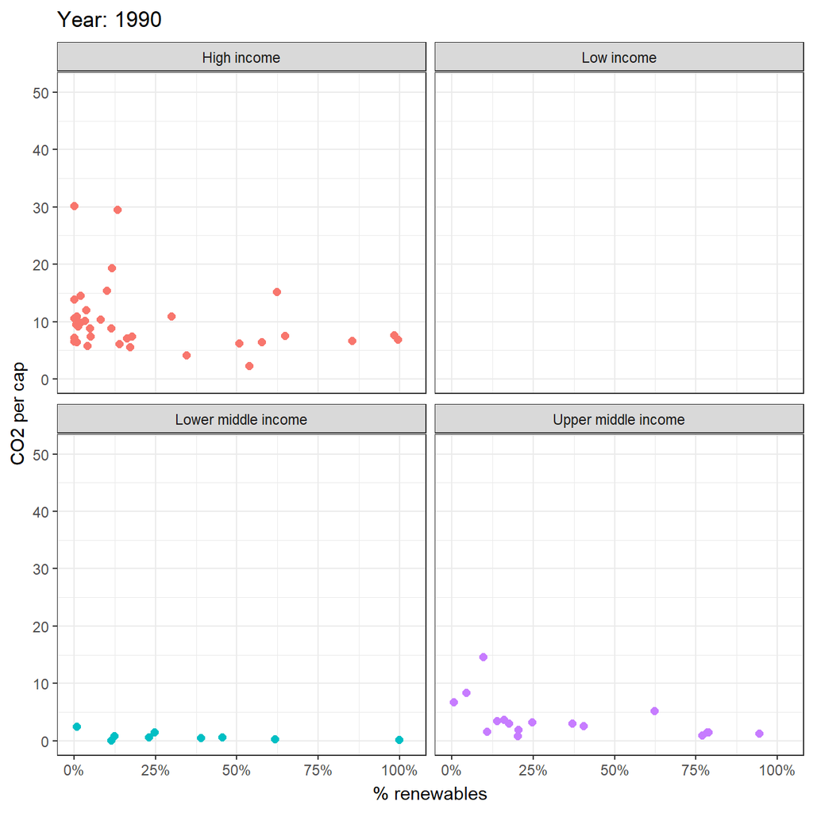

```r
library(gifski)
library(png)

energy[,c("variable","iso3c","year","value")] %>%

  #subsetting required rows from energy dataset based on the variable column (types of energy)
  filter(variable %in% c("elec_hydro", "elec_solar", "elec_wind", "elec_renew_other","elecprod")) %>%

  #pivot wider based on the variable electricity type
  pivot_wider(names_from = variable, values_from = value) %>%

  #calculate sum of renewable energy and % of renewable contribution to total (elecprod)
  mutate(renewable_energy = elec_hydro + elec_solar + elec_wind + elec_renew_other,
         percent_renewable_contribution = renewable_energy/elecprod) %>%

  #joining with Co2 per capita dataset based on columns iso3c (code) and year: value = CO2 per capita
  inner_join(co2_percap, by = c("iso3c", "year" = "date")) %>%

  #Joining with dataset specifying income level of countries based on col iso3c
  inner_join (countries, by="iso3c") %>%

  #Subsetting only required columns
  select(iso3c,country, year, income_level, percent_renewable_contribution, value) %>%
  rename(CO2_per_cap = value) %>%
  arrange(desc(percent_renewable_contribution)) %>%

  #Plotting ggplot graph (% renewable contribution vs CO2 per cap)
  ggplot(aes(x=percent_renewable_contribution, y=CO2_per_cap, color=income_level)) +
  geom_point(size=2) +
  scale_x_continuous(labels = scales::percent_format()) +
  facet_wrap(~income_level) +
  theme_bw() +
  theme(legend.position = "none") +
  labs(title = 'Year: {frame_time}',
       x = '% renewables',
       y = 'CO2 per cap') +

  #Animating ggplot graph
  transition_time(as.integer(year)) +
  ease_aes('linear')
```

General Observations:

> In high income and upper middle income countries, there is a more pronounced relationship over the years between CO2 per cap reduction and % renewable increase. Countries in these 2 categories also have much higher CO2 per cap output than low and lower middle income and show higher variability in CO2 emissions as seen from the vertical movement of points in the animation. The lower middle and low income countries have lower CO2 per capita emissions and we do not see a change in these emissions as the % of renewable energy change. In the high income nations, the decrease in CO2 emissions over time could be a result of the Paris Agreement that was signed in 2015.

> Lower income countries are very often developing nations which took longer to get access to renewable technology. We also note that in the earlier years we do not have as much data for the low and lower middle income countries compared to the high and upper middle income nations.